# In Search of Sadness

Unveiling the saddest classical masterpieces using Spotify API and spotifyr

Emily Wang

Updated: 2023-07-19

# 1 Introduction

In the modern age, music has become an art form that we experience far more than any other. We walk, bike, and skateboard around campus with earbuds and headphones. We leave Spotify running in the background while we work, with extensive playlists at our fingertips.

Luckily, it seems that it’s not possible to listen to too much music. Generally speaking, music doesn’t harm your lungs, damage your liver, or leave you in financial debt. As a classically trained musician with over 15 years of experience listening to music, I’d consider it one of the most worthwhile hobbies one can have.

Despite the lack of physiological burden, there is no doubt that we hear emotion in music to the extent that we are *moved* … which seems a bit paradoxical at first. How do we interpret sounds as containing sentiment in music without lyrics?

The feelings stoked by music seem to be on another level than that of words. Words can invoke excitement, but music invokes wonder. Some may argue that a poem may transcend you to a higher plane if you read or write it while tipsy or intoxicated… but that means poisoning your liver, and we’re back at square one.

Perhaps there is a difference between [“perceived emotions”](https://journals.sagepub.com/doi/abs/10.1177/10298649020050S105), and “felt emotions”, the latter being more intense. Moreover, art has the capability of using perceived emotions to transform negative experiences into positive ones.

Our own pursuit of understanding sadness in music raises this question: why do people deliberately immerse themselves in sad music, when in real life we would avoid events that would cause us sadness? A [survey study](https://journals.plos.org/plosone/article?id=10.1371/journal.pone.0110490) reveals that the most common emotion reflected by individuals after listening to sad music was nostalgia with a majority of positive emotions such as peacefulness. Participants sought sad music as a way to live through negative life experiences vicariously without consequences.

I understand that the subject of this study may have taken you aback at first, since, why would anyone deliberately search for sadness in their already miserable life? But consider these revelations and my intentions; let us discover the most depressing classical tunes so that we may listen to them and fondly remember since sadness exists, we might as well feel and *enjoy* it in its pure form.

Alright, I hope you’re as excited as I am; let’s get right to it!

To start off, I will access the [Spotify Web API](https://developer.spotify.com/documentation/web-api), which allows developers to access Spotify’s vast music catalog, obtain specific user-related data, and even manage playlists on behalf of users. I will utilize the audio analysis data that Spotify API provides for individual tracks, which will be from various ‘This Is’ playlists from renowned classical musicians. I chose the Spotify curated ‘This Is’ playlist as I believe provides a definitive collection of an artist’s most popular and significant songs.

As the largest music streaming platform, Spotify offers many features that I utilize/enjoy, including:

- **Discover Weekly**: a playlist of ~30 songs that Spotify’s algorithms curate based on the user’s listening history, favorite tracks, and music preferences, updated weekly.
- **Spotify Blend**: a collaborative playlist feature that allows two or more Spotify users to merge their musical tastes into a single playlist, generated using tracks from both users’ libraries while taking into account their individual listening history and favorite songs. The playlist is updated regularly to reflect changes in their musical preferences, enabling users to discover new music together and celebrate their shared tastes
- **Spotify Wrapped**: an annual feature and campaign by Spotify that provides users with personalized insights, highlights, and summary statistics about their music listening habits over the past year, such as their top artists, favorite genres, and the total amount of time spent on the platform. The feature is usually presented in a visually appealing format that users can easily share on social media platforms.

# 2 Data Retrieval

There were a few external tasks I completed to begin this analysis:

- First, I created my app in the [API Website](https://developer.spotify.com/documentation/web-api),
- obtained the keys (Client ID and Client Secret) for future requests, and
- compiled a list of *This Is* playlists from composers of my choosing

```r
#Load the necessary libraries
library(spotifyr)
library(tidyverse)
```

```r
#Web API Credentials
Sys.setenv(SPOTIFY_CLIENT_ID = "21692352f75144598888b96c09618192")
Sys.setenv(SPOTIFY_CLIENT_SECRET = "143388b177ff45159b6d60b69c828bcc")

access_token <- get_spotify_access_token()
```

## 2.1 Dataframe creation

I complied this file containing `This Is` is playlists from well-known classical composers with a few of my favorite modern film composers, totaling 33 musicians.

```r
playlistURI <- read.csv("classical_this_is-URI.csv", header = T, sep = ",")

print(playlistURI$Playlist)
```

```
##  [1] "Bach"          "Mozart"        "Beethoven"     "Rachmaninoff"
##  [5] "Schumann"      "Glass"         "Monteverdi"    "Handel"
##  [9] "Vivaldi"       "Debussy"       "Tchaikovsky"   "Haydn"
## [13] "Elgar"         "Verdi"         "Wagner"        "Strauss II"
## [17] "Mahler"        "Schubert"      "Saint-Saëns"   "Hisaishi"
## [21] "Stravinsky"    "Chopin"        "Mendelssohn"   "Shostakovich"
## [25] "Brahms"        "Dvořák"        "Bernstein"     "John Williams"
## [29] "Liszt"         "Grieg"         "Sibelius"      "Paganini"
## [33] "Zimmer"
```

Next, using the `spotifyr` library:

- Obtain tracks from each playlist using `get_playlist_tracks`
- Obtain audio features data using `get_track_audio_features`

```r
df <- data.frame()

#Iterate for each This Is playlist
for (i in 1:nrow(playlistURI)) {
  playlist_id <- playlistURI$URI[i]
  tracks <- get_playlist_tracks(playlist_id, fields = c('track.id','track.name'))

  # Iterate for each track in playlist
  for (j in 1:nrow(tracks)) {
    track_id <- tracks[j, 'track.id']
    track_name <- tracks[j, 'track.name']
    artist <- playlistURI[i,1]
    features <- get_track_audio_features(track_id)

    # Create a new row with the Name, Artist, and track.name columns
    new_row <- cbind(data.frame(Artist = artist, Track = track_name, stringsAsFactors = FALSE), features)

    # Append the new row to the data frame
    df <- rbind(df, new_row)
  }
}
```

Great! The resulting dataframe contains information on the Artist, Track Name, and audio features for 2141 different tracks.

## 2.2 Audio Features Description

Below are descriptions of features we will be using in this analysis from the [Spotify Web API Get Track’s Audio Features](https://developer.spotify.com/documentation/web-api/reference/get-audio-features):

> - **Danceability**: Describes how suitable a track is for dancing based on a combination of musical elements including tempo, rhythm stability, beat strength, and overall regularity. A value of 0.0 is least danceable and 1.0 is most danceable.
> - **Energy**: Is a measure from 0.0 to 1.0 and represents a perceptual measure of intensity and activity. Typically, energetic tracks feel fast, loud, and noisy. For example, death metal has high energy, while a Bach prelude scores low on the scale. Perceptual features contributing to this attribute include dynamic range, perceived loudness, timbre, onset rate, and general entropy.
> - **Key**: The key the track is in. Integers map to pitches using standard Pitch Class notation. E.g. 0 = C, 1 = C#/Db, 2 = D, and so on.
> - **Loudness**: The overall loudness of a track in decibels (dB). Loudness values are averaged across the entire track and are useful for comparing relative loudness of tracks. Loudness is the quality of a sound that is the primary psychological correlate of physical strength (amplitude). Values typically range between -60 and 0 db.
> - **Mode**: Mode indicates the modality (major or minor) of a track, the type of scale from which its melodic content is derived. Major is represented by 1 and minor is 0.
> - **Valence**: A measure from 0.0 to 1.0 describing the musical positiveness conveyed by a track. Tracks with high valence sound more positive (e.g. happy, cheerful, euphoric), while tracks with low valence sound more negative (e.g. sad, depressed, angry).
> - **Speechiness**: Speechiness detects the presence of spoken words in a track. The more exclusively speech-like the recording (e.g. talk show, audio book, poetry), the closer to 1.0 the attribute value. Values above 0.66 describe tracks that are probably made entirely of spoken words. Values between 0.33 and 0.66 describe tracks that may contain both music and speech, either in sections or layered, including such cases as rap music. Values below 0.33 most likely represent music and other non-speech-like tracks.
> - **Tempo**: The overall estimated tempo of a track in beats per minute (BPM). In musical terminology, tempo is the speed or pace of a given piece and derives directly from the average beat duration.

# 3 Data Visualization

```r
#Load the necessary libraries
library(ggplot2)
library(ggrepel)
library(ggridges)
library(viridis)
library(RColorBrewer)
library(scales)
library(fmsb)
```

## 3.1 Energy vs. Valance

Right off the bat, the valance and energy metrics can tell us the musical sadness of a piece. For example, sad songs tend to be low in energy - less noisy and more sparse. They also convey low valence, indicating musical negativeness.

### 3.1.1 Energy vs. Valance Gradient

Here, I’ve used a gradient based on each track’s positions relative to the mean position to visualize the relationship between energy and valence.

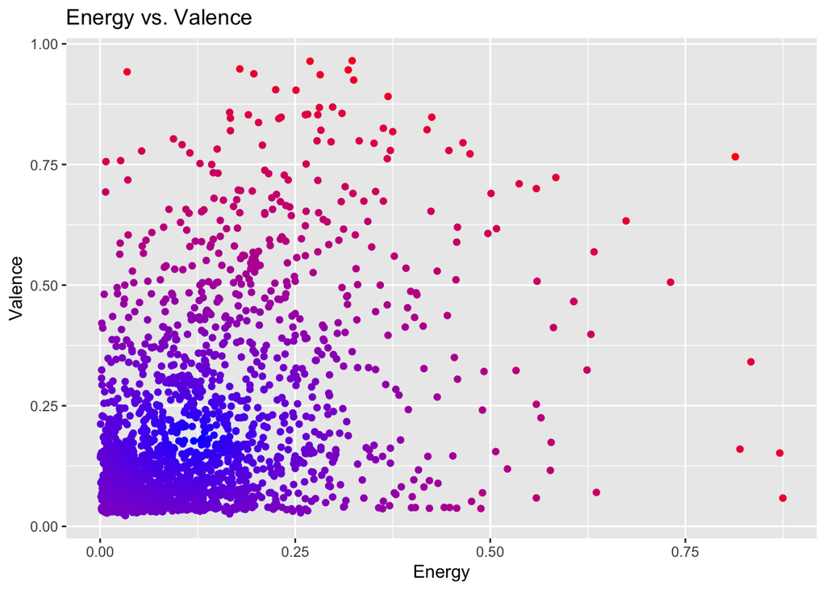

```r
df %>% ggplot(aes(x = energy, y = valence, color = sqrt((energy - mean(energy))^2 + (valence - mean(valence))^2))) +
  geom_point() +
  scale_color_gradient(low = "blue", high = "red") +  # Specify the color gradient
  labs(x = "Energy", y = "Valence") +
  ggtitle("Energy vs. Valence") +
  theme(legend.position="none")
```

These classical pieces tend toward the lower half of the energy metric, and the lowest quadrant of the valence metric.

### 3.1.2 Energy vs. Valence by Composer

Using the average mean and average valance of all the tracks for each composer as a generalization, we can pinpoint trends in the musical sadness of each composer’s work.

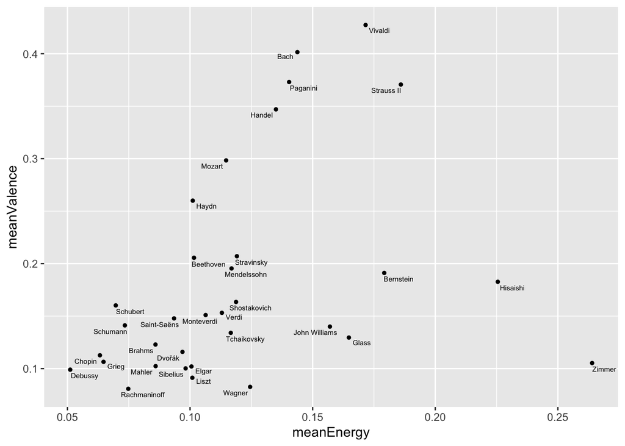

```r
df %>%
  group_by(Artist) %>%
  summarize(meanEnergy = mean(energy), meanValence = mean(valence)) %>%
  ggplot(aes(meanEnergy, meanValence, label = Artist)) +
  geom_point(size = 1) +
  geom_text_repel(box.padding = 0.1,  # Adjust the distance between label and data point
    point.padding = .5,  # Adjust the distance between label and plot edges
    size = 2, vjust = 0)
```

Relatively modern composers such as Berstein, Hisaishi, Zimmer, John Williams, and Glass tend to have higher mean energy, with relatively low valence. It is also not surprising that Vivaldi, Bach, Handel, and Paganini, Strauss II have pieces that exhibit higher energy and valance: Vivaldi’s and Paganini’s music often feature virtuosic passages and lively rhythms, Bach’s and Handel’s pieces cover a wide emotional spectrum, and Strauss II’s waltzes are characterized by joyful melodies.

I had anticipated that Debussy might dominate this particular comparison with his unique style tending toward musical color rather than structure. Any passerby of his Clair de Lune will acknowledge its incredible atmospheric sound and texture. However, I would say that his pieces express musical “journeys” rather than concrete emotions.

## 3.2 Distance Metric

A piece with 0.0 valence and 0.0 energy — located at the origin on our previous visualization — will have the highest quantifiable musical sadness. I created the `distance` metric using a basic distance formula.

```r
df <- df %>% mutate(distance = sqrt(energy^2 + valence^2))

df %>% select(distance, Track, Artist) %>% arrange(distance) %>% mutate(Track= substr(Track, 1, 60))
```

| distance | Track | Artist |
| --- | --- | --- |
| 0.02902723 | Sent Here for a Reason | Zimmer |
| 0.02943362 | 4 Pezzi sacri: I. Ave Maria | Verdi |
| 0.03034589 | Symphony No. 1 in D Minor, Op. 13: III. Larghetto | Rachmaninoff |
| 0.03118654 | Stravinsky: L'Oiseau de feu, Tableau I: Introduction - Le ja | Stravinsky |
| 0.03134087 | Saint-Saëns: Symphony No. 3 in C Minor, Op. 78 "Organ Sympho | Saint-Saëns |
| 0.03174103 | Lyric Pieces IV, Op. 47: No. 3 Melodie | Grieg |
| 0.03223536 | The Creation, Hob. XXI:2: Pt. I, No.1: Die Vorstellung des C | Haydn |
| 0.03228536 | Calme des nuits, Op. 68, No. 1 | Saint-Saëns |
| 0.03241686 | Nocturnes: No. 1. Nuages | Debussy |
| 0.03274037 | Elegy, Op. 58 | Elgar |

[output cut: 2131 more lines]

To consider its lyrical sadness, I simply did a Google search and came upon the [translated lyrics](https://www.metorchestramusicians.org/ave-maria-from-verdis-otello/):

> Hail Mary, full of grace, chosen among wives and maidens art thou,  
> blessed be the fruit, o blessed one, of thy womb, Jesus.  
> Pray for the one who kneels in prayer before you, pray for the sinner, for the one who is  
> innocent, and for the weak and oppressed, and for the mighty, also wretched, show thy mercy.  
> Pray for the one who bows his head  
> under injustice and under misfortune;  
> for us, pray thou for us, pray ever and in the hour of our death,  
> pray for us, pray for us, pray.  
> Hail Mary . . in the hour of our death.  
> Hail! . . . Amen!

## 3.3 Musical Key Signature

If we want to find the saddest tracks, we can’t forget to analyze key signature! Even you only have the slightest knowledge of music theory, you might have wondered why music written in minor keys are usually sad whereas major keys are happy. Or perhaps you’ve noticed the dramatic effect that changing keys has on a piece. This mostly has to do with western music history, cultural exposure, and connections to vocal tonality.

Let’s take a look at whether the tracks in our dataset show any trends when classified by key and mode (major/minor) in conjunction with energy and valence.

Christian Schubart puts the differences between Key Signatures into words crisply in an excerpt from [Ideen zu einer Aesthetik der Tonkunst (1806)](https://www.wmich.edu/mus-theo/courses/keys.html):

> **C Major**: Completely Pure. Its character is: innocence, simplicity, naïvety, children’s talk.  
> **C Minor**: Declaration of love and at the same time the lament of unhappy love. All languishing, longing, sighing of the love-sick soul lies in this key.  
> **Db Major**: A leering key, degenerating into grief and rapture. It cannot laugh, but it can smile; it cannot howl, but it can at least grimace its crying.–Consequently only unusual characters and feelings can be brought out in this key.  
> **C# Minor**: Penitential lamentation, intimate conversation with God, the friend and help-meet of life; sighs of disappointed friendship and love lie in its radius.  
> **D Major**: The key of triumph, of Hallejuahs, of war-cries, of victory-rejoicing. Thus, the inviting symphonies, the marches, holiday songs and heaven-rejoicing choruses are set in this key.  
> **D Minor**: Melancholy womanliness, the spleen and humours brood.  
> **Eb Major**: The key of love, of devotion, of intimate conversation with God.  
> **D# Minor**: Feelings of the anxiety of the soul’s deepest distress, of brooding despair, of blackest depresssion, of the most gloomy condition of the soul. Every fear, every hesitation of the shuddering heart, breathes out of horrible D# minor. If ghosts could speak, their speech would approximate this key.  
> **E Major**: Noisy shouts of joy, laughing pleasure and not yet complete, full delight lies in E Major.  
> **E minor**: Naïve, womanly innocent declaration of love, lament without grumbling; sighs accompanied by few tears; this key speaks of the imminent hope of resolving in the pure happiness of C major.  
> **F Major**: Complaisance & Calm.  
> **F Minor**: Deep depression, funereal lament, groans of misery and longing for the grave. **F# Major**: Triumph over difficulty, free sigh of relief utered when hurdles are surmounted; echo of a soul which has fiercely struggled and finally conquered lies in all uses of this key.  
> **F# Minor**: A gloomy key: it tugs at passion as a dog biting a dress. Resentment and discontent are its language.  
> **G Major**: Everything rustic, idyllic and lyrical, every calm and satisfied passion, every tender gratitude for true friendship and faithful love,–in a word every gentle and peaceful emotion of the heart is correctly expressed by this key.  
> **G Minor**: Discontent, uneasiness, worry about a failed scheme; bad-tempered gnashing of teeth; in a word: resentment and dislike.  
> **Ab Major**: Key of the grave. Death, grave, putrefaction, judgment, eternity lie in its radius.  
> **Ab Minor**: Grumbler, heart squeezed until it suffocates; wailing lament, difficult struggle; in a word, the color of this key is everything struggling with difficulty.  
> **A Major**: This key includes declarations of innocent love, satisfaction with one’s state of affairs; hope of seeing one’s beloved again when parting; youthful cheerfulness and trust in God.  
> **A minor**: Pious womanliness and tenderness of character.  
> **Bb Major**: Cheerful love, clear conscience, hope aspiration for a better world.  
> **Bb minor**: A quaint creature, often dressed in the garment of night. It is somewhat surly and very seldom takes on a pleasant countenance. Mocking God and the world; discontented with itself and with everything; preparation for suicide sounds in this key.  
> **B Major**: Strongly coloured, announcing wild passions, composed from the most glaring coulors. Anger, rage, jealousy, fury, despair and every burden of the heart lies in its sphere.  
> **B Minor**: This is as it were the key of patience, of calm awaiting ones’s fate and of submission to divine dispensation.

```r
#Function to convert key numeric to comprehensible character
get_key_name <- function(key_number) {
  key_names <- c("C", "C#/Db", "D", "D#/Eb", "E", "F", "F#/Gb", "G", "G#/Ab", "A", "A#/Bb", "B")
  return(key_names[key_number + 1])
}
```

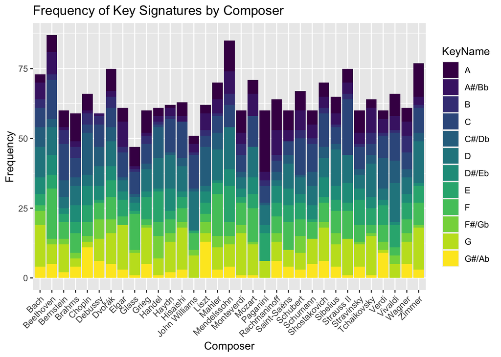

```r
# Create a column for pitch notation
df <- df %>%
  mutate(KeyName = sapply(key, get_key_name))

key_counts <- df %>%
  group_by(Artist, KeyName) %>%
  tally()

# Sort the key_counts data frame by the most frequent key signatures for each composer
key_counts <- key_counts %>%
  arrange(Artist, desc(n))

# Create the bar plot
color_palette <- viridis(7)
ggplot(key_counts, aes(x = Artist, y = n, fill = KeyName)) +
  geom_bar(stat = "identity") +
  labs(title = "Frequency of Key Signatures by Composer",
       x = "Composer", y = "Frequency") +
  scale_fill_viridis(discrete = TRUE) +
  theme(axis.text.x = element_text(angle = 45, hjust = 1))
```

### 3.3.1 Energy vs. Valence vs. Key vs. Modality

Let’s get a better understanding of how key, modality, energy, and valence are correlated.

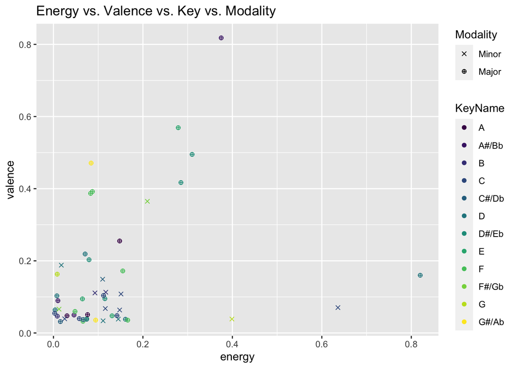

```r
#Take a random sample
df_sample <- sample_n(df, 50)

df_sample %>% ggplot(aes(x = energy, y = valence, shape = factor(mode))) +
  geom_point(aes(color = KeyName)) +
  scale_color_viridis(discrete = T) +
  scale_shape_manual(values = c(4, 10), labels = c("Minor", "Major")) +
  labs(title = "Energy vs. Valence vs. Key vs. Modality", shape = "Modality")
```

There certainly seems to be a correlation between valence and modality; minor keys tend to be low in valence, producing a negative connotation!

# 4 Radar Charts

To compare different composers, I’ve created some pretty radar charts. First, I’ll take a look at modern film composers.

```r
mean_data <- df %>%
  group_by(Artist) %>%
  summarize(
    danceability = mean(danceability),
    energy = mean(energy),
    loudness = mean(loudness),
    speechiness = mean(speechiness),
    valence = mean(valence),
    tempo = mean(tempo)
  )

# Normalize the averages in the mean_data dataframe
mean_data_normalized <- mean_data %>%
  mutate(across(danceability:tempo, scales::rescale))
```

```r
selected_artists <- c("Hisaishi", "John Williams", "Zimmer", "Bernstein")

# Subset the 'mean_data_normalized' dataframe based on the selected artist names
mean_data_subset <- subset(mean_data_normalized, Artist %in% selected_artists)

artists <- mean_data_subset$Artist

mean_data_subset <- mean_data_subset[,-1]
# Assign 'Artist' column to the row names
rownames(mean_data_subset) <- artists
```

### 4.0.1 Modern Composers

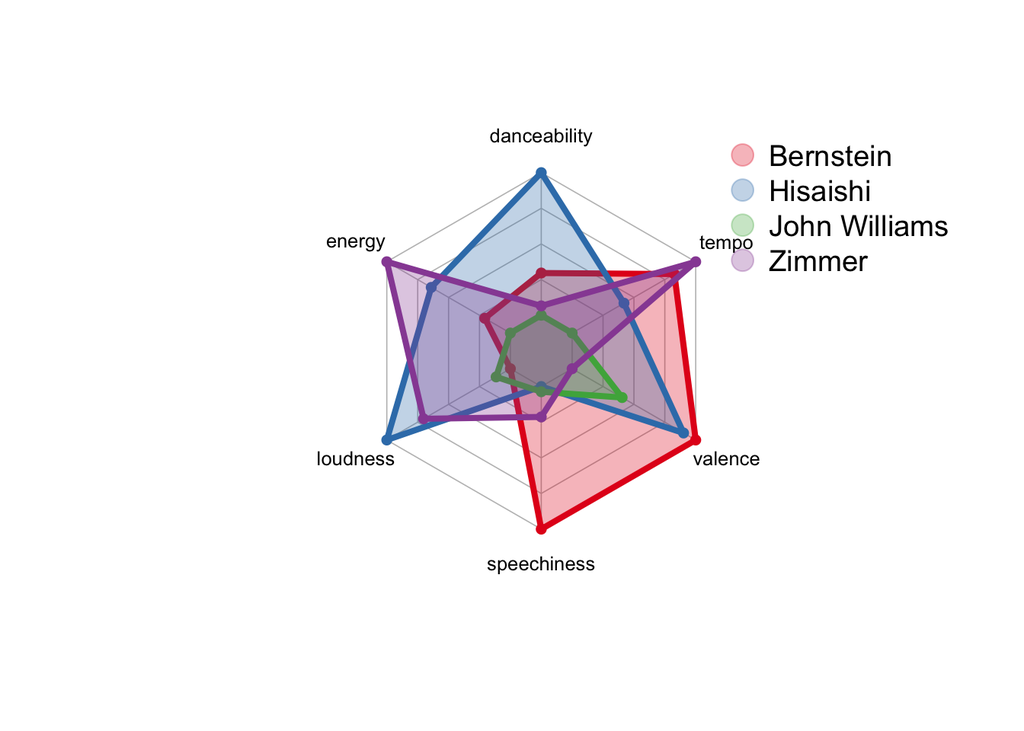

```r
# Set graphic colors
coul <- brewer.pal(9, "Set1")
colors_border <- coul
colors_in <- alpha(coul, 0.3)

# Set up the radar chart for the subsetted data
radarchart(mean_data_subset, maxmin = FALSE,
           # Custom polygon
           pcol = colors_border, pfcol = colors_in, plwd = 4, plty = 1,
           # Custom the grid
           cglcol = "grey", cglty = 1, axislabcol = "black",
           caxislabels = seq(0, 1, 0.2), cglwd = 0.8,
           # Custom labels
           vlcex = 0.8)

# Manually create the legend with the correct artist names
legend("topright", legend = rownames(mean_data_subset),
       bty = "n", pch = 20, col = colors_in,
       cex = 1.2, pt.cex = 3)
```

### 4.0.2 Baroque Composers (1600 - 1750)

```r
selected_artists <- c("Bach", "Handel", "Monteverdi", "Vivaldi")

# Subset the 'mean_data_normalized' dataframe based on the selected artist names
mean_data_subset <- subset(mean_data_normalized, Artist %in% selected_artists)

artists <- mean_data_subset$Artist

mean_data_subset <- mean_data_subset[,-1]
# Assign 'Artist' column to the row names
rownames(mean_data_subset) <- artists
```

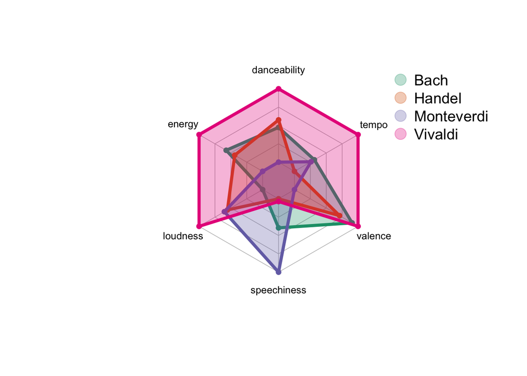

```r
# Set graphic colors
coul <- brewer.pal(8, "Dark2")
colors_border <- coul
colors_in <- alpha(coul, 0.3)

# Set up the radar chart for the subsetted data
radarchart(mean_data_subset, maxmin = FALSE,
           # Custom polygon
           pcol = colors_border, pfcol = colors_in, plwd = 4, plty = 1,
           # Custom the grid
           cglcol = "grey", cglty = 1, axislabcol = "black",
           caxislabels = seq(0, 1, 0.2), cglwd = 0.8,
           # Custom labels
           vlcex = 0.8)

# Manually create the legend with the correct artist names
legend("topright", legend = rownames(mean_data_subset),
       bty = "n", pch = 20, col = colors_in,
       cex = 1.2, pt.cex = 3)
```

### 4.0.3 Classical Composers (1750–1820)

```r
selected_artists <- c("Haydn", "Mozart", "Schubert", "Beethoven", "Paganini")

# Subset the 'mean_data_normalized' dataframe based on the selected artist names
mean_data_subset <- subset(mean_data_normalized, Artist %in% selected_artists)

artists <- mean_data_subset$Artist

mean_data_subset <- mean_data_subset[,-1]
# Assign 'Artist' column to the row names
rownames(mean_data_subset) <- artists
```

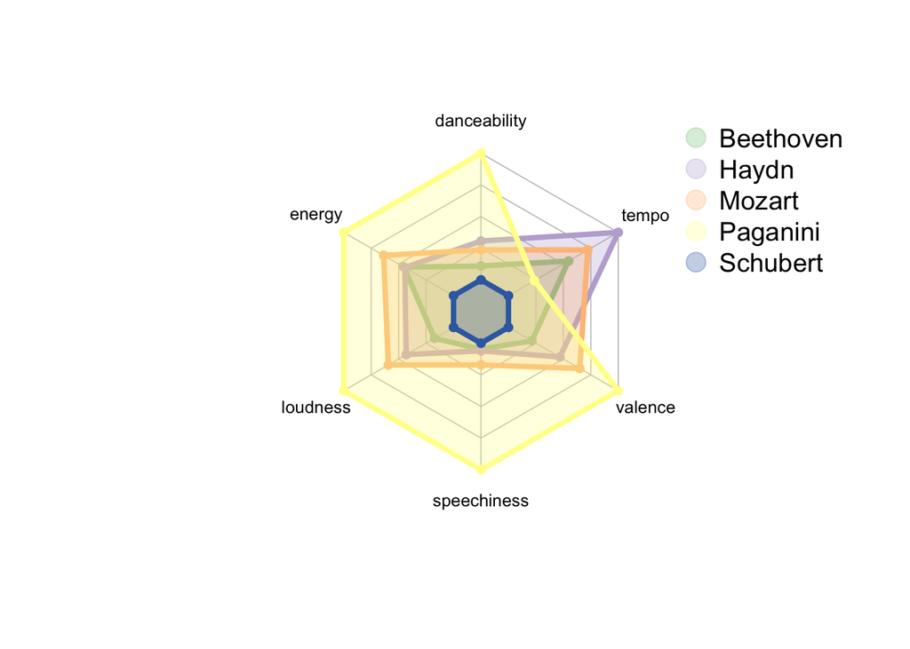

```r
# Set graphic colors
coul <- brewer.pal(8, "Accent")
colors_border <- coul
colors_in <- alpha(coul, 0.3)

# Set up the radar chart for the subsetted data
radarchart(mean_data_subset, maxmin = FALSE,
           # Custom polygon
           pcol = colors_border, pfcol = colors_in, plwd = 4, plty = 1,
           # Custom the grid
           cglcol = "grey", cglty = 1, axislabcol = "black",
           caxislabels = seq(0, 1, 0.2), cglwd = 0.8,
           # Custom labels
           vlcex = 0.8)

# Manually create the legend with the correct artist names
legend("topright", legend = rownames(mean_data_subset),
       bty = "n", pch = 20, col = colors_in,
       cex = 1.2, pt.cex = 3)
```

With the exception of Paganini (who would compose his own works to showcase his virtuosity), these Classical Era composers seem to have more noticeable balance of each element.

### 4.0.4 Romantic Composers (1820-1900)

```r
selected_artists <- c("Chopin", "Liszt", "Verdi", "Wagner", "Tchaikovsky", "Brahms", "Mahler", "Rachmaninoff")

# Subset the 'mean_data_normalized' dataframe based on the selected artist names
mean_data_subset <- subset(mean_data_normalized, Artist %in% selected_artists)

artists <- mean_data_subset$Artist

mean_data_subset <- mean_data_subset[,-1]
# Assign 'Artist' column to the row names
rownames(mean_data_subset) <- artists
```

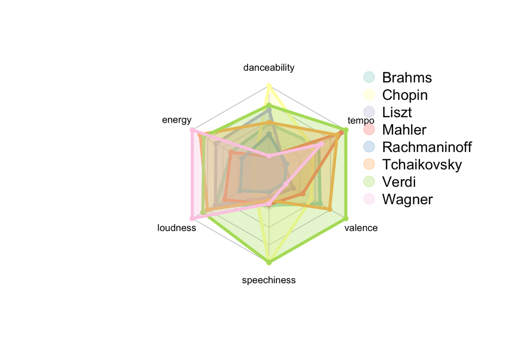

```r
# Set graphic colors
coul <- brewer.pal(12, "Set3")
colors_border <- coul
colors_in <- alpha(coul, 0.3)

# Set up the radar chart for the subsetted data
radarchart(mean_data_subset, maxmin = FALSE,
           # Custom polygon
           pcol = colors_border, pfcol = colors_in, plwd = 4, plty = 1,
           # Custom the grid
           cglcol = "grey", cglty = 1, axislabcol = "black",
           caxislabels = seq(0, 1, 0.2), cglwd = 0.8,
           # Custom labels
           vlcex = 0.8)

# Manually create the legend with the correct artist names
legend("topright", legend = rownames(mean_data_subset),
       bty = "n", pch = 20, col = colors_in,
       cex = 1.2, pt.cex = 3)
```

### 4.0.5 20th century Composers

```r
selected_artists <- c("Elgar", "Stravinsky", "Shostakovich")

# Subset the 'mean_data_normalized' dataframe based on the selected artist names
mean_data_subset <- subset(mean_data_normalized, Artist %in% selected_artists)

artists <- mean_data_subset$Artist

mean_data_subset <- mean_data_subset[,-1]
# Assign 'Artist' column to the row names
rownames(mean_data_subset) <- artists
```

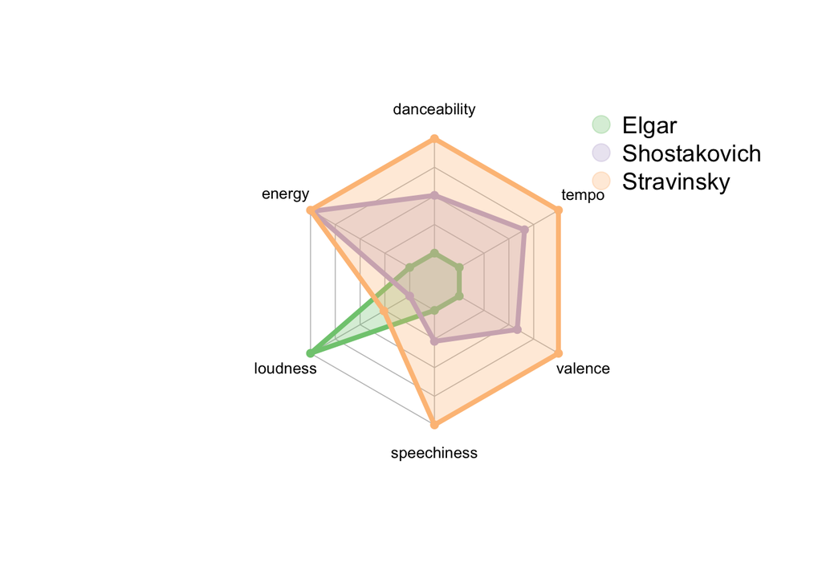

```r
# Set graphic colors
coul <- brewer.pal(2, "Accent")
colors_border <- coul
colors_in <- alpha(coul, 0.3)

# Set up the radar chart for the subsetted data
radarchart(mean_data_subset, maxmin = FALSE,
           # Custom polygon
           pcol = colors_border, pfcol = colors_in, plwd = 4, plty = 1,
           # Custom the grid
           cglcol = "grey", cglty = 1, axislabcol = "black",
           caxislabels = seq(0, 1, 0.2), cglwd = 0.8,
           # Custom labels
           vlcex = 0.8)

# Manually create the legend with the correct artist names
legend("topright", legend = rownames(mean_data_subset),
       bty = "n", pch = 20, col = colors_in,
       cex = 1.2, pt.cex = 3)
```

Overall, there seems to be a lack of correlation between the audio features of pieces written by composers in similar time periods.

# 5 Context/Sadness over time

Composers also may develop and change their styles based on real life events. To visualize this, I created an example using a ridgeline plot of a composer’s symphonies to chart their music’s sentiment over time.

Of course, there is a limitation to this method; the movements of symphonies conventionally involve different tempos, keys, and emotions conveyed.

## 5.1 Tchaikovsky’s Symphonies

Tchaikovsky is a composer whose hidden gems are tumultuous and emotionally deep, in comparison to his more famous works such as The Nutcracker. Some argue that you could find evidence of his bipolar depression in his music, the outlet for his emotions. Although the sad nature of Tchaikovsky has not been notable throughout this analysis, understanding a composer’s intentions may elevate the pain felt by an audience.

Let’s examine the sound of his symphonies over time: Symphony No. 1 in G minor, Op. 13, “Winter Dreams” (composed in 1866) Symphony No. 2 in C minor, Op. 17, “Little Russian” (composed in 1872) Symphony No. 3 in D major, Op. 29, “Polish” (composed in 1875) Symphony No. 4 in F minor, Op. 36 (composed in 1877-1878) Symphony No. 5 in E minor, Op. 64 (composed in 1888) Symphony No. 6 in B minor, Op. 74, “Pathétique” (composed in 1893)

```r
dftchaikovskySymphs <- data.frame()

tchaikovskySymphs <- get_playlist_tracks('6gMCMxKfZ7HMc0KZ9jNhMO', fields = c('track.id','track.name'))

    for (i in 1:nrow(tchaikovskySymphs)) {
      track_id <- tchaikovskySymphs[i, 'track.id']
      track_name <- tchaikovskySymphs[i, 'track.name']
      features <- get_track_audio_features(track_id)

    # Create a new row with the Name, Artist, and track.name columns
      new_row <- cbind(data.frame(Track = track_name, stringsAsFactors = FALSE), features)

    # Append the new row to the data frame
      dftchaikovskySymphs <- rbind(dftchaikovskySymphs, new_row)
    }
```

```r
dftchaikovskySymphs <- dftchaikovskySymphs %>%
  mutate(Date = case_when(
    startsWith(Track, "Symphony No. 1") ~ "1866",  # Replace "First Condition" with the desired date or value
    startsWith(Track, "Symphony No. 2") ~ "1872", # Replace "Second Condition" with the desired date or value
    # Add more conditions as needed
    startsWith(Track, "Symphony No. 3") ~ "1875",
    startsWith(Track, "Symphony No. 4") ~ "1878",
    startsWith(Track, "Symphony No. 5") ~ "1888",
    startsWith(Track, "Symphony No. 6") ~ "1893",
  ))

dftchaikovskySymphs <- dftchaikovskySymphs %>% mutate(distance = sqrt(energy^2 + valence^2))
```

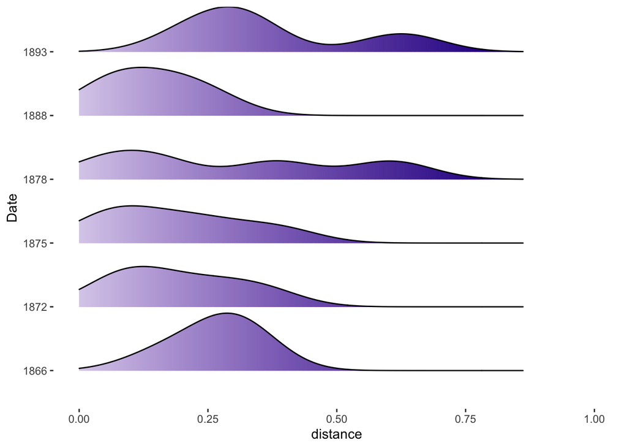

```r
dftchaikovskySymphs %>% ggplot(aes(x = distance, y = Date, fill = ..x..)) +
  geom_density_ridges_gradient(scale = 0.9) +
  scale_fill_gradient(low = "white", high = "blue4") +
  theme(panel.background = element_rect(fill = "white")) +
  theme(plot.background = element_rect(fill = "white")) +
  xlim(0,1) +
  theme(legend.position = "none")
```

The 4th movement in Tchaikovsky’a final symphony is some of the most devastating music I have ever heard. However, it seems that several of his previous symphonies had a more consistent musical sadness.

## 5.2 Beethoven’s Symphonies

Beethoven, arguably the most influential and celebrated composer in western music history, was deeply passionate and devoted to music throughout his life. Let’s examine the sound of his symphonies over time! Symphony No. 1 in C major, Op. 21 (composed in 1800) Symphony No. 2 in D major, Op. 36 (composed in 1802) Symphony No. 3 in E-flat major, Op. 55, “Eroica” (composed in 1803-1804) Symphony No. 4 in B-flat major, Op. 60 (composed in 1806) Symphony No. 5 in C minor, Op. 67 (composed in 1807-1808) Symphony No. 6 in F major, Op. 68, “Pastoral” (composed in 1808) Symphony No. 7 in A major, Op. 92 (composed in 1811-1812) Symphony No. 8 in F major, Op. 93 (composed in 1812) Symphony No. 9 in D minor, Op. 125, “Choral” (composed in 1822-1824)

```r
dfbeethovenSymphs <- data.frame()

beethovenSymphs <- get_playlist_tracks('2Bt6tMlDniOU4tYlcnMyA1', fields = c('track.id','track.name'))

    for (i in 1:nrow(beethovenSymphs)) {
      track_id <- beethovenSymphs[i, 'track.id']
      track_name <- beethovenSymphs[i, 'track.name']
      features <- get_track_audio_features(track_id)

    # Create a new row with the Name, Artist, and track.name columns
      new_row <- cbind(data.frame(Track = track_name, stringsAsFactors = FALSE), features)

    # Append the new row to the data frame
      dfbeethovenSymphs <- rbind(dfbeethovenSymphs, new_row)
    }
```

```r
dfbeethovenSymphs <- dfbeethovenSymphs %>%
  mutate(Date = case_when(
    startsWith(Track, "Beethoven: Symphony No. 1") ~ "1801",  # Replace "First Condition" with the desired date or value
    startsWith(Track, "Beethoven: Symphony No. 2") ~ "1802", # Replace "Second Condition" with the desired date or value
    # Add more conditions as needed
    startsWith(Track, "Beethoven: Symphony No. 3") ~ "1804",
    startsWith(Track, "Beethoven: Symphony No. 4") ~ "1806",
    startsWith(Track, "Beethoven: Symphony No. 5") ~ "1807",
    startsWith(Track, "Beethoven: Symphony No. 6") ~ "1808",

    startsWith(Track, "Beethoven: Symphony No. 7") ~ "1811",
    startsWith(Track, "Beethoven: Symphony No. 8") ~ "1812",
    startsWith(Track, "Beethoven: Symphony No. 9") ~ "1824"
  ))

dfbeethovenSymphs <- dfbeethovenSymphs %>% mutate(distance = sqrt(energy^2 + valence^2))
```

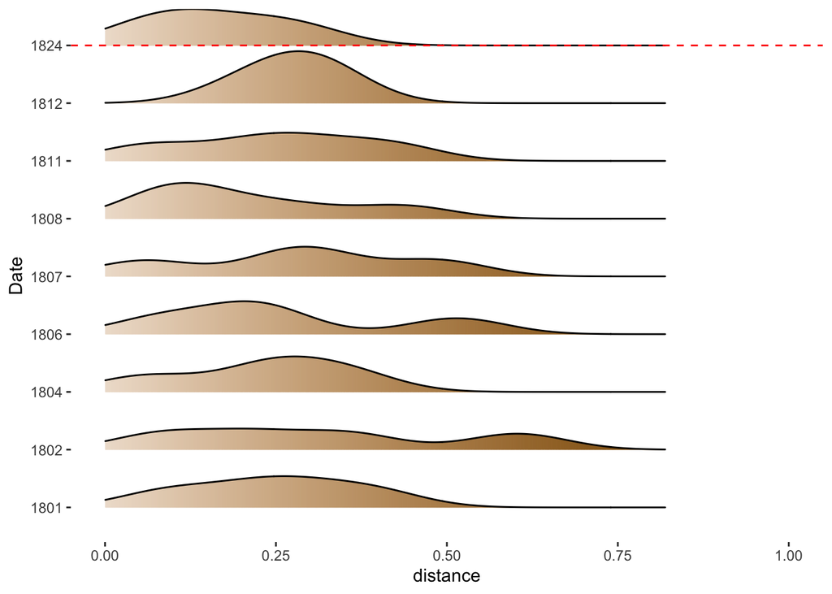

```r
dfbeethovenSymphs %>% ggplot(aes(x = distance, y = Date, fill = ..x..)) +
  geom_density_ridges_gradient(scale = 0.9) +
  scale_fill_gradient(low = "white", high = "orange4") +
  theme(panel.background = element_rect(fill = "white")) +
  theme(plot.background = element_rect(fill = "white")) +
  xlim(0,1) +
  geom_hline(yintercept = 9, linetype = "dashed", color = "red") +
  theme(legend.position = "none")
```

Beethoven is generally thought to have gone deaf between 1818 and 1820, which I’ve highlighted with the red dashed line. Interestingly, his last symphony does seem to exhibit more musical sadness than his previous works!

# 6 Limitations of Analysis

There are several limitations to this analysis that I will address:

- I chose well-known composers for this analysis; we may be able to narrow down our search further if I took survey information of the saddest composers ranked by humans for the initial playlist list.
- The robust track audio features provided by Spotify are not always representative when describing a piece. These statistics are not exclusive to classical music, and the `instrumentalness`, `liveness`, and `acousticness` were not applicable to pieces in this case while they may been for other genres.
- There is a lack of consideration for other connections to human sadness, such as a violin mimicking that of a lamenting voice, or glissandos that sound like a tear-filled whimper such as in Mahler’s “Ich bin der Welt abhanden gekommen”. A lamenting violin may statistically exhibit high valence and energy despite the contrasting interpretation of humans. Vocal connections can greatly increase the “musical sadness” of a piece, but this is difficult to quantify.
- Spotify API rate limit prevents the retrival of more than X amount of tracks at a time, which can limit the net we can cast to find songs.

## 6.1 Future Work

- Continue searching for sadness in modern songs with lyrics using sentiment analysis
- More pretty visualizations?